# User Guide

Kenneth Condon

2018-05-12

# 1 Introduction

This package is an adaptable and efficient implementation of the tau specificity algorithm[^1] benchmarked in 2016 by Kryuchkova-Mostacci & Robinson-Rechavi[^2]. To utilise this downstream RNA-seq analysis step, the user first runs their own RNA-seq analysis pipeline and normalisation steps to produce a set of counts (e.g. FPKM, RPKM, TPM) for each gene in each tissue according to the user preference. Many algorithms have been developed for measuring tissue specificity, and they all fall into 1 of 2 categories:

- Algorithms that reduce the tissue specificity of a gene to a single value as a global measure of the gene’s specificity
- Algorithms that reduce the tissue specificity of a gene to a set of values, 1 per tissue, as a profile of the specificity of a gene for each tissue

The tau specificity algorithm was implemented in this package because:

- Tau is consistently robust
- Tau results between different data set sizes show the highest correlation
- Tau does not show bias toward finding housekeeping genes
- Tau finds the greatest number of tissue specific genes
- Enrichment analysis shows that the functions of those tissue specific genes found only by tau are consistent with the functions of the tissues in which they are found

Using both human and mouse RNA-seq data, the benchmark paper compared 9 algorithms:

- Raw counts
- Tau[^3]
- Gini coefficient[^4]
- Tissue specificity index (TSI)[^5]
- Shannon entropy (Hg)[^6]
- Z-score[^7]
- Specificity measure (SPM)[^8]
- Expression enrichment (EE)[^9]
- Preferential expression measure (PEM)[^10].

The results of the benchmark paper (fig. 1) show that every algorithm produces a bimodal distribution identifying 3 clear groups:

- 0-0.2 tissue specificity (non/low specificity, housekeeping genes)
- 0.2-0.8 tissue specificity (intermediate specificity)
- 0.8-1.0 tissue specificity (high/absolute specificity)

The authors identified the best performing algorithms as tau, gini and counts. However the authors state that counts is only robust if the correct expression threshold/cut-off is chosen and gini doesn’t normalise for expression amplitude between tissues, while tau normalises for amplitude between tissues and also includes the number of tissues as part of the algorithm.

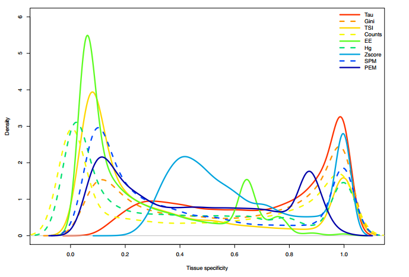

Figure 1: Distribution of tissue specificity by algorithm taken from the 2016 benchmark paper

The key conclusions of the benchmark were as follows:

- Tau showed the strongest correlation between results regardless of tissue numbers included
- Of the 9 algorithms compared in the benchmark paper, only tau avoided a bias toward classifying most genes as housekeeping and as a possible consequence, tau identified the most tissue specific genes including genes not detected by any other algorithm
- Gene Ontology enrichment suggests the extra tissue specific genes found by tau were due to false negatives in other algorithms rather than false positives in tau
- Additionally, the authors compared the effect of calculating tissue specificity using RPKM values or log transformed values and found:
  - Using RPKM detects more tissue specificity to the extent that the 0-0.2 tissue specificity group (housekeeping genes) may be lost completely
  - Using RPKM reduces correlation between both between tissue subsets and between species.

# 2 Workflow

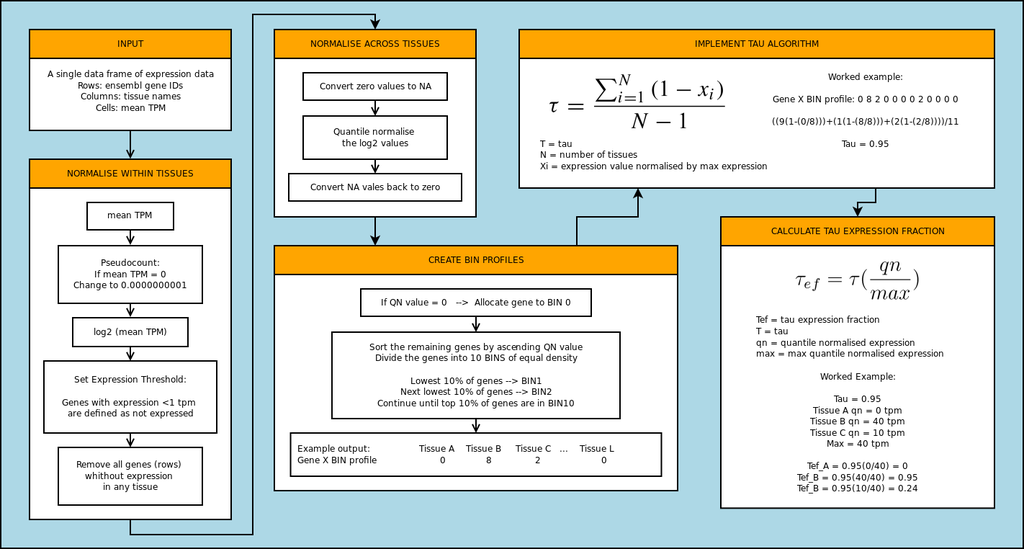

Figure 2: Calculating tissue specificity

## 2.1 Input

Users run their preferred RNA-seq analysis pipeline to calculate a single expression value for each gene in each tissue (e.g. mean TPM). Currently the package supports data from mouse, human and macaque. All genes should named by their Ensembl Gene IDs (e.g. ENSMUSG00000066232). This is to allow biomaRt annotation later in the workflow. Take care to annotate all genes using the same ensembl version (all versions from ensembl 79 onward are supported). This is important to ensure no genes are excluded from the pipeline due to discontinued Ensembl Gene IDs. The package takes as input a single dataframe where the first column is the Ensembl Gene ID, each subsequent column header is a tissue name, and the cells contain the user defined expression values of all genes in all tissues.

```r
library(tispec)
head(meanExp[,1:5], n=5)
>                      tissueA   tissueB   tissueC   tissueD   tissueE
> ENSMUSG00000014301 3.6301193 2.0391600 1.4472250 1.8513800 0.5247505
> ENSMUSG00000073609 0.0000000 0.0000000 0.0000000 0.0000000 0.0000000
> ENSMUSG00000020928 6.0836047 0.2638565 0.9679230 0.1412985 1.0217450
> ENSMUSG00000018102 5.4114287 0.3318635 0.0383125 0.0883085 0.1128075
> ENSMUSG00000021986 0.1242874 0.0308725 0.0708935 0.0878305 0.0089120

checkInput(meanExp[,1:5])
> tissueA tissueB tissueC tissueD tissueE
>       0       0       0       0       0
```

The checkInput function evaluates the cells of the dataframe to ensure it is in the correct format i.e. The function returns errors when it finds cells that contain character strings, NAs, negative values or infinite values. In the example above, only the first five tissues are checked. The number of incorrectly formatted cells are returned for each tissue.

## 2.2 Normalisation

```r
log2Exp <- log2Tran(meanExp)
```

```r
head(log2Exp[,1:5], n=5)
>                      tissueA  tissueB   tissueC  tissueD    tissueE
> ENSMUSG00000014301 1.8600170 1.027975 0.5332892 0.888601 0.00000000
> ENSMUSG00000020928 2.6049264 0.000000 0.0000000 0.000000 0.03103518
> ENSMUSG00000018102 2.4360095 0.000000 0.0000000 0.000000 0.00000000
> ENSMUSG00000057836 0.1464763 0.000000 0.0000000 0.000000 0.00000000
> ENSMUSG00000031200 2.9537600 1.964720 1.1524982 1.384296 0.24553826
```

```r
qnExp <- quantNorm(log2Exp)
```

```r
head(qnExp[,1:5], n=5)
>                    tissueA tissueB tissueC tissueD tissueE
> ENSMUSG00000014301   2.070   1.058   0.514   1.063   0.000
> ENSMUSG00000020928   2.911   0.000   0.000   0.000   0.033
> ENSMUSG00000018102   2.702   0.000   0.000   0.000   0.000
> ENSMUSG00000057836   0.161   0.000   0.000   0.000   0.000
> ENSMUSG00000031200   3.309   2.141   1.045   1.611   0.287
```

## 2.3 Calculate Tissue Specificity

After normalisation, implementation of the tau specificity algorithm assigns each gene a tau value between 0-1.

- Absolutely specific genes (ASGs):
  - Genes expressed in a single tissue only
  - Defined by a tau value of 1
- Highly specific genes (HSGs):
  - Genes with relatively highly enriched expression in a few tissues
  - Defined by a tau value of at least 0.85.
- Housekeeping genes:
  - Genes expressed in many (or all) tissues with no enriched expression
  - Defined by a tau value of at most 0.2.

The tau value only defines the “specificity” of a gene. To determine which tissue the gene is actually specific for, requires calculation of tau expression fractions (Tef). As can be seen in the worked example in figure 2, gene X is a HSG with a tau value of 0.95. However, calculating Tef identifies that Gene X is highly specific for tissue B (0.95 Tef), with additional but much lower specificity for tissue C (0.24 Tef). Targetting gene X in tissue B, may produce off-target effects in tissue C.

```r
tauExp <- calcTau(qnExp)
```

```r
head(tauExp[,1:5], n=5)
>                      tau tissueA tissueB tissueC tissueD
> ENSMUSG00000000001 0.611   0.487   0.303   0.022   0.462
> ENSMUSG00000000003 0.911   0.000   0.000   0.000   0.000
> ENSMUSG00000000028 0.619   0.016   0.415   0.363   0.081
> ENSMUSG00000000037 0.964   0.000   0.000   0.000   0.000
> ENSMUSG00000000049 0.653   0.637   0.301   0.080   0.219
```

The output of ‘calcTau’ now begins with an extra column containing the tau value of each gene, while each tissue column is now populated with tau expression fractions.

## 2.4 Biomart Annotation

Next, using the biomaRt package, the gene name and type are added to each ensembl gene ID.

```r
tauAnno <- getMart(x = 'mouse', y = 79, z = tauExp)
```

```r
head(tauAnno[,1:5], n=5)
>                    external_gene_name   gene_biotype   tau tissueA tissueB
> ENSMUSG00000000001              Gnai3 protein_coding 0.611   0.487   0.303
> ENSMUSG00000000003               Pbsn protein_coding 0.911   0.000   0.000
> ENSMUSG00000000028              Cdc45 protein_coding 0.619   0.016   0.415
> ENSMUSG00000000037              Scml2 protein_coding 0.964   0.000   0.000
> ENSMUSG00000000049               Apoh protein_coding 0.653   0.637   0.301
```

The dataframe output now contains all the information required for easy user interaction.

# 3 Additional Useful Functions

## 3.1 Specific gene distribution

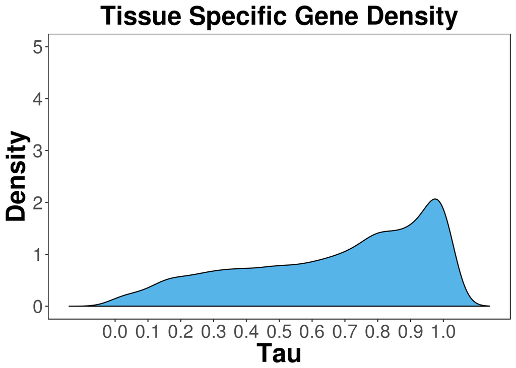

```r
plotDensity(tauAnno)
```

Notice the similarity between the shape of this plot andTau plotted in Figure 1 with a peak at tau>0.95. The plots are not highly similar because here a much reduced dataset is plotted (~9k genes only). Expect a distribution similar to Figure 1 when all annotated genes are included (~40k genes).

## 3.2 Specific gene counts

```r
asg <- getDist(tauAnno, 1)
head(asg, n = 5)
>         protein_coding miRNA lincRNA total
> tissueA            117     5       0   122
> tissueB              7     0       0     7
> tissueC             16     0       0    16
> tissueD              0     0       0     0
> tissueE             13     0       0    13

hsg <- getDist(tauAnno, 0.85)
head(hsg, n = 5)
>         protein_coding miRNA lincRNA total
> tissueA            482    11       0   493
> tissueB             75     1       0    76
> tissueC            124     3       0   127
> tissueD             15     0       0    15
> tissueE             74     2       0    76
```

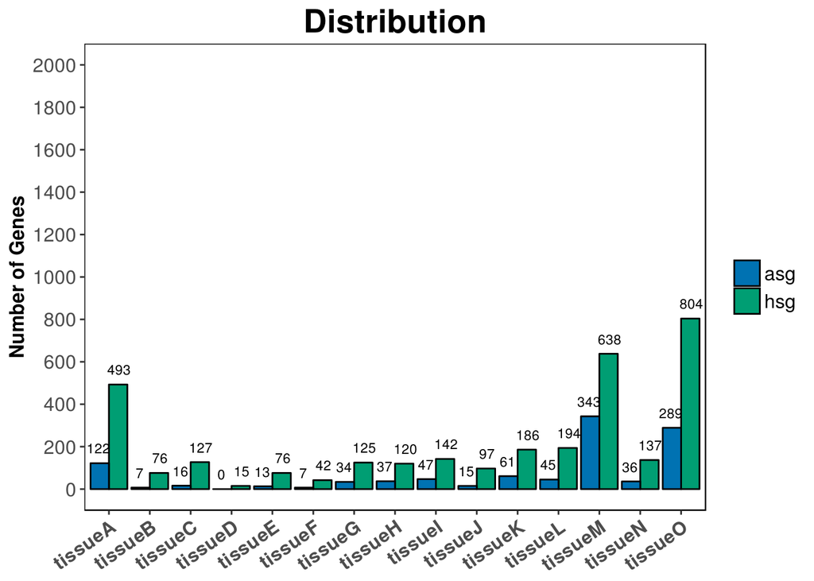

```r
plotDist(tauAnno)
```

The distribution plot identifies tissueM and tissueO as the tissues with the highest number of absolutely specific genes (ASGs, tau = 1) and highly tissue specific genes (HSGs, tau >= 0.85)

## 3.3 Study a tissue of interest

### 3.3.1 Extract your tissue

```r
tissueA <- getTissue('tissueA', qnExp, tauAnno)
```

```r
head(tissueA[, -2], n = 5)
>                    external_gene_name   tau  frac    qn score
> ENSMUSG00000000001              Gnai3 0.611 0.487 2.833 0.752
> ENSMUSG00000000003               Pbsn 0.911 0.000 0.000 0.000
> ENSMUSG00000000028              Cdc45 0.619 0.016 0.030 0.019
> ENSMUSG00000000037              Scml2 0.964 0.000 0.000 0.000
> ENSMUSG00000000049               Apoh 0.653 0.637 2.499 0.871
```

The function getTissue retrieves the quantile normalised expression and tissue specificity of every gene in a named tissue and uses this information to create a score column. Each gene’s score is between 0 and 2, and is the sum of it’s tau expression fraction value and it’s 0-1 ranged normalised expression value. The gene with both the highest expression and specificity recieves the highest score.

Notice Scml2 is a highly specific gene (tau 0.964) but not for tissueA (frac 0.000) and is not even expressed in tissueA (qn 0.000). To identify for which tissue Scml2 is specific requires the plotGene function. However, organising the data like this allows multiple other useful functions: getOptimum, plotCorr, and getControls.

### 3.3.2 Get a highly specific, highly expressed, optimal gene set

Ranking of genes by both expression and specificity is useful for anyone working on a single tissue wanting to identify a set of genes 1) that are highly specific to the tissue, 2) that are expressed in high enough quantities (facilitates bench work in the laboratory), and 3) with minimal expression in other tissues (limits off target effects)

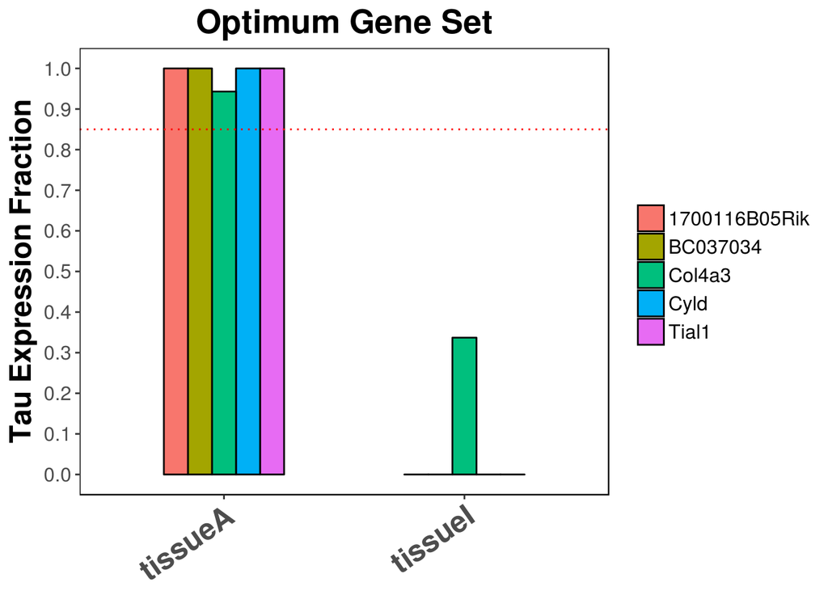

```r
optimum <- getOptimum(tauAnno, tissueA, 5)
optimum$dataframe[, -2]
>                    external_gene_name   tau  frac     qn score
> ENSMUSG00000030846              Tial1 1.000 1.000 10.684 2.000
> ENSMUSG00000092276      1700116B05Rik 1.000 1.000  8.561 1.801
> ENSMUSG00000079465             Col4a3 0.943 0.943  8.191 1.710
> ENSMUSG00000036948           BC037034 1.000 1.000  7.020 1.657
> ENSMUSG00000036712               Cyld 1.000 1.000  6.977 1.653

optimum$barplot
```

Extract the gene expression values to see the high expression in tissueA, and minimal expression elsewhere:

```r
meanExp[c(rownames(optimum$dataframe)),]
>                      tissueA   tissueB   tissueC   tissueD   tissueE
> ENSMUSG00000030846 539.78368 0.1148720 0.0037990 0.0175125 0.0037425
> ENSMUSG00000092276 197.22271 0.0421595 0.0913875 0.0596790 0.1215310
> ENSMUSG00000079465 176.62340 0.0662970 0.0223990 0.0021085 0.0046770
> ENSMUSG00000036948  72.35674 0.0145925 0.3263185 0.0044990 0.5621460
> ENSMUSG00000036712  71.23815 0.0144965 0.0257650 0.0038840 0.0592730
>                      tissueF   tissueG   tissueH   tissueI   tissueJ
> ENSMUSG00000030846 0.0276585 0.0088765 0.0552765 0.0061370 0.0008880
> ENSMUSG00000092276 0.0375185 0.0650285 0.0834180 0.0344150 0.2275565
> ENSMUSG00000079465 0.0607450 0.0412175 0.3254935 6.9372550 0.0066290
> ENSMUSG00000036948 0.0016440 0.0259750 0.1074240 0.0273470 0.2556060
> ENSMUSG00000036712 0.0039460 0.0056310 0.0120100 0.0049445 0.0578330
>                      tissueK   tissueL  tissueM   tissueN    tissueO
> ENSMUSG00000030846 0.0181350 0.1392860 0.003171 0.6912925 0.29473000
> ENSMUSG00000092276 0.0242000 0.8026370 0.000000 0.0610585 0.10229889
> ENSMUSG00000079465 0.0133460 0.2099100 0.000827 0.0201425 0.33874778
> ENSMUSG00000036948 0.0263065 0.1034235 0.000000 0.0096230 0.10712111
> ENSMUSG00000036712 0.0032290 0.0441515 0.000000 0.1597550 0.03447556
```

### 3.3.3 Plot correlation between specificity and expression

Visualising the relationship between specificity and correlation in a tissue helps us conceptualise the nature of tissue specific genes in a tissue. Also, with this function a gene of interest can be highlighted to see how it compares to the rest of the genes in the tissue in terms of expression and specificity.

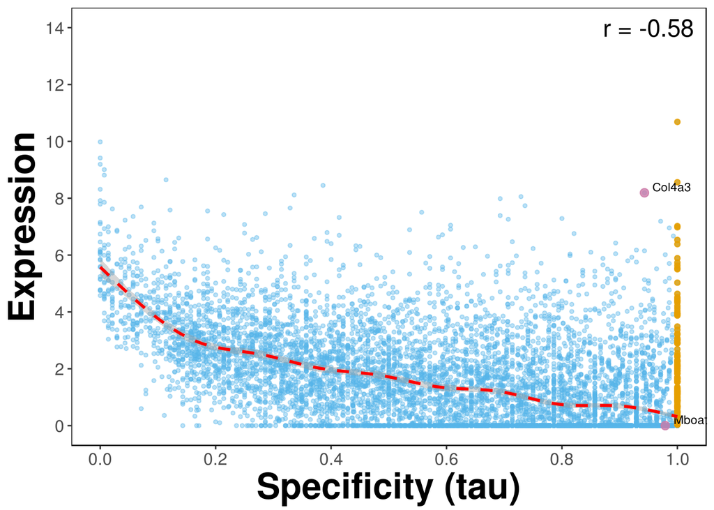

```r
corrPlots <- plotCorr(tissueA, c('Col4a3', 'Mboat7'))
corrPlots$tauPlot
```

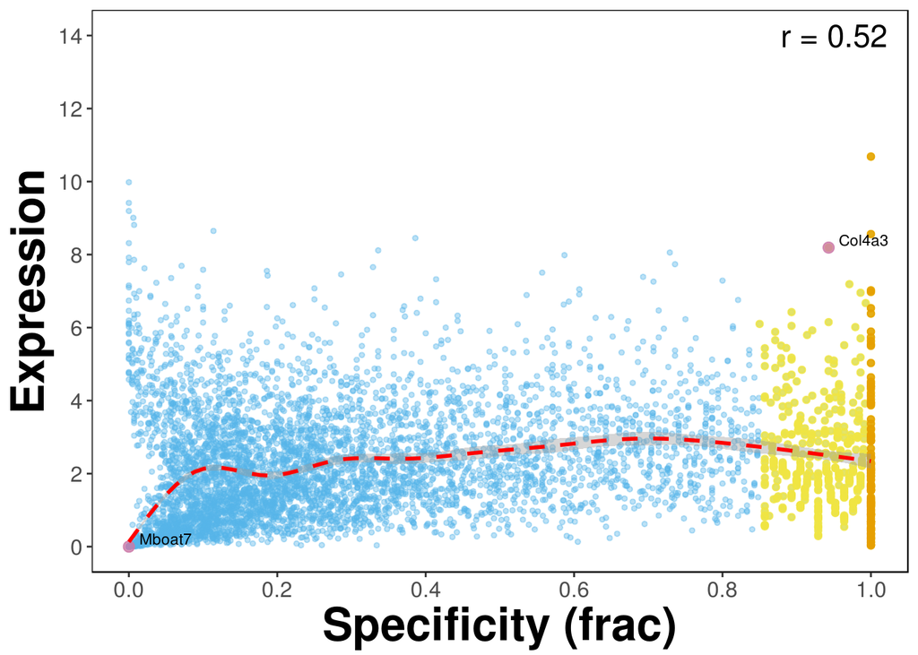

```r
corrPlots$fracPlot
> `geom_smooth()` using method = 'gam'
```

By plotting the tau expression value against expression we see that as specificity of a gene **for tissueA** increases above 0.1, there is actually little effect on expression in tissueA. There is a positive correlation (r = 0.52). However, the trendline shows an initial strong positive correlation that plateaus above 0.1 specificity (frac). This is clearly shown by the wide range of expression of genes that are absolutely specific (orange) or highly specific (yellow) for tissueA. From this plot we can now see that of both genes passed by the user, only Col4a3 is highly specific to tissueA because the tau expression fractions for tissueA were used. To extract genes that are both highly specific and highly expressed use getOptimum. Try passing the results of getOptimum to this function: in what area of the scatter plot do you think those genes will be plotted?

### 3.3.4 Get a set of control genes

This function is useful for differentiating between two tissues. For example, to determine if a small sample of suprachiasmtic nucleus brain tissue has been contaminated with cortex brain tissue during tissue dissection. Performing qPCR on the top ranked genes returned by the function will confirm/reject contamination.

```r
controls <- getControls(tissueA, tissueB)

head(controls$tissueA[, -2], n = 1)
>                    external_gene_name tau frac     qn score
> ENSMUSG00000030846              Tial1   1    1 10.684     2

head(controls$tissueB[, -2], n = 1)
>                    external_gene_name   tau  frac    qn score
> ENSMUSG00000035596             Mboat7 0.979 0.979 7.471 1.678
```

## 3.4 Study a gene of interest

Quite often a researcher works on a specific gene rather than a tissue and may find this function useful to identify the specificity of a single gene for any and all tissues. This function can also be used to confirm the results from other functions in this package e.g. getOptimum.

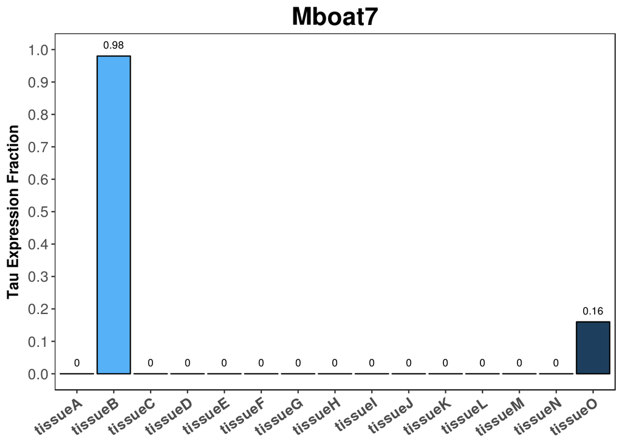

```r
plotGene(tauAnno, 'Mboat7') # gene name is case sensitive
```

This function is simply plotting the gene from the result of getMart:

```r
subset(tauAnno, tauAnno$external_gene_name == 'Mboat7')
>                    external_gene_name   gene_biotype   tau tissueA tissueB
> ENSMUSG00000035596             Mboat7 protein_coding 0.979       0   0.979
>                    tissueC tissueD tissueE tissueF tissueG tissueH tissueI
> ENSMUSG00000035596       0       0       0       0       0       0       0
>                    tissueJ tissueK tissueL tissueM tissueN tissueO
> ENSMUSG00000035596       0       0       0       0       0   0.156
```

Viewing the input expression values of the gene confirms the plot output:

```r
id <- rownames(subset(tauAnno, tauAnno$external_gene_name == 'Mboat7'))
round(meanExp[id, ], digits = 3)
>                    tissueA tissueB tissueC tissueD tissueE tissueF tissueG
> ENSMUSG00000035596       0 121.734   0.013   0.152       0   0.067   0.019
>                    tissueH tissueI tissueJ tissueK tissueL tissueM tissueN
> ENSMUSG00000035596       0   0.002   0.003       0       0       0   0.026
>                    tissueO
> ENSMUSG00000035596   7.043
```

[^1]: Yanai, I., Benjamin, H., Shmoish, M., Chalifa-Caspi, V., Shklar, M., Ophir, R., Bar-Even, A., Horn-Saban, S., Safran, M., Domany, E., Lancet, D., Shmueli, O., 2005. Genome-wide midrange transcription profiles reveal expression level relationships in human tissue specification. Bioinformatics (Oxford, England). 21, 650-659.
[^2]: Kryuchkova-Mostacci, N. & Robinson-Rechavi, M., 2016. A benchmark of gene expression tissue-specificity metrics. Briefings in Bioinformatics.
[^3]: Yanai, I., Benjamin, H., Shmoish, M., Chalifa-Caspi, V., Shklar, M., Ophir, R., Bar-Even, A., Horn-Saban, S., Safran, M., Domany, E., Lancet, D., Shmueli, O., 2005. Genome-wide midrange transcription profiles reveal expression level relationships in human tissue specification. Bioinformatics (Oxford, England). 21, 650-659.
[^4]: Lidia Ceriani & Paolo Verme, 2012. “The origins of the Gini index: extracts from Variabilità e Mutabilità (1912) by Corrado Gini,” The Journal of Economic Inequality, Springer;Society for the Study of Economic Inequality, vol. 10(3), pages 421-443, September.
[^5]: Julien, P., Brawand, D., Soumillon, M., Necsulea, A., Liechti, A., Schutz, F., Daish, T., Grutzner, F., Kaessmann, H., 2012. Mechanisms and evolutionary patterns of mammalian and avian dosage compensation. PLoS Biology. 10, e1001328.
[^6]: Schug, J., Schuller, W.P., Kappen, C., Salbaum, J.M., Bucan, M., Stoeckert, C.J.,Jr, 2005. Promoter features related to tissue specificity as measured by Shannon entropy. Genome Biology. 6, R33.
[^7]: Vandenbon, A. & Nakai, K., 2010. Modeling tissue-specific structural patterns in human and mouse promoters. Nucleic Acids Research. 38, 17-25.
[^8]: Xiao, S.J., Zhang, C., Zou, Q., Ji, Z.L., 2010. TiSGeD: a database for tissue-specific genes. Bioinformatics (Oxford, England). 26, 1273-1275.
[^9]: Yu, X., Lin, J., Zack, D.J., Qian, J., 2006. Computational analysis of tissue-specific combinatorial gene regulation: predicting interaction between transcription factors in human tissues. Nucleic Acids Research. 34, 4925-4936.
[^10]: Huminiecki, L., Lloyd, A.T., Wolfe, K.H., 2003. Congruence of tissue expression profiles from Gene Expression Atlas, SAGEmap and TissueInfo databases. BMC Genomics. 4, 31.